# Sentence Reading Task Results

### Plots

Here are a few boxplots by participant. These plots show the distribution of responses per participant in both taps (Figure 1) and trills (Figure 2) between the pre and post tests.

**Figure 1: Productions of taps per participant during the pre and post test**

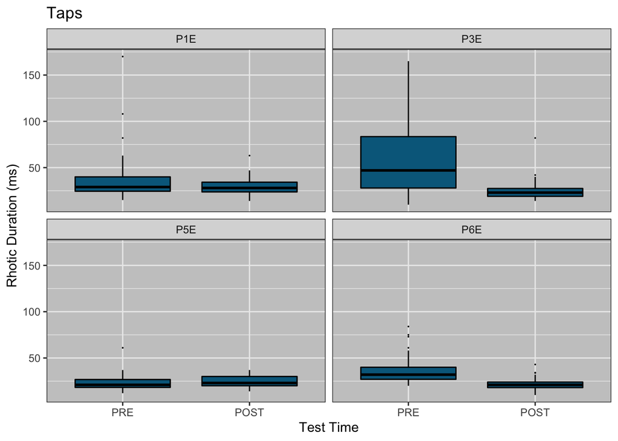

**Figure 2: Productions of trills per participant during the pre and post test**

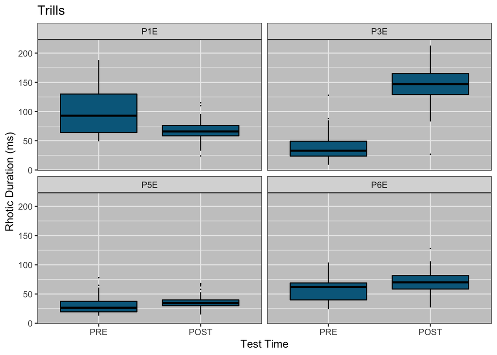

### Conclusions

It looks like there is good evidence that training worked for P3E, while P1E did show a decrease in duration for taps, but not an increase for trills, though this effect was small. P5E did not appear to respond to training, as pre and post tests were inconclusive. Overall, adding more participants should reveal whether there is a group trend and paint a clearer picture in terms of how much variation in the effectiveness of training exists.